# Презентация по выполнению индивидуального проекта №1

Основы информационной безопасности

Дворкина Е. В

Российский университет дружбы народов, Москва, Россия

2 марта 2024

# Информация

## Докладчик

- Дворкина Ева Владимировна
- студентка группы НКАбд-01-22
- Российский университет дружбы народов
- https://vk.com/yuri.kamori

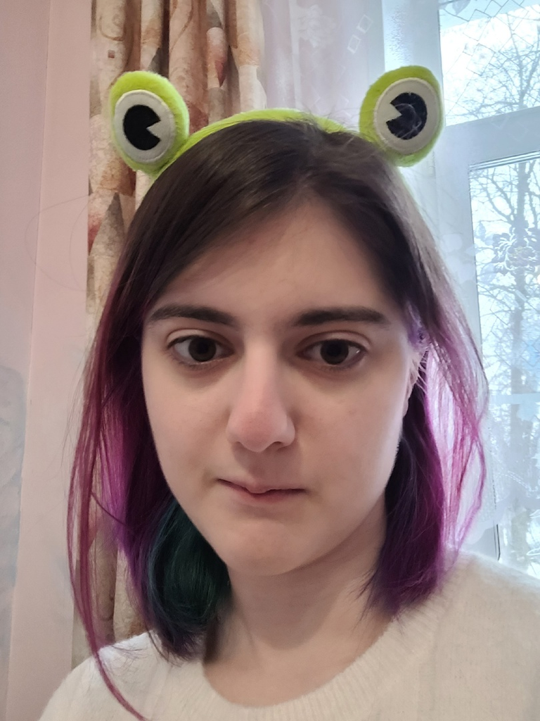

## Цель

Приобретение практических навыков по установке операционной системы Linux на виртуальную машину.

- Необходимо установить дистрибутив Kali Linux на виртуальную машину VirtualBox.

# Выполнение первого этапа проекта

## Создание виртуальной машины

Открываю VirtualBox, нажимаю `создать`, в появившемся окне выбираю тип операционной системы Linux, версия - Debian, задаю имя машины (рис. 1).

[figure not shown]

Выбор имени и операционной системы

## Создание виртуальной машины

Соглашаюсь с получившимися характеристиками, жму `готово` (рис. 4).

[figure not shown]

Окно создания виртуальной машины

## Создание виртуальной машины

Подключаю ранее скачанный образ диска

[figure not shown]

Подключение образа диска

## Установка операционной системы на виртуальную машину

В окне установки Kali выбираю графическую установку

[figure not shown]

Выбор способа установки

## Настройка имени компьютера

Ввожу имя компьютера

[figure not shown]

Ввод имени компьютера

## Настройка пользователей

Ввожу имя пользователя, у которой будут права суперпользователя (рис. 13).

[figure not shown]

Настройка учетной записи

## Разметка дисков

Теперь установщик проверяет диски и предлагает различные варианты, в зависимости от настроек. Созданный виртуальный диск чистый, поэтому я выбираю «весь диск»

[figure not shown]

Разметка дисков

## Разметка дисков

Убеждаюсь, что выбран нужный виртуальный диск, продолжаю настройку разметки дисков

[figure not shown]

Разметка дисков

## Разметка дисков

После этого этапа надо подтвердить окончание разметки дисков, чтобы изменения были записаны

[figure not shown]

Разметка дисков

## Установка метапакетов

Далее я могу выбрать, какие метапакеты (пустые пакеты, которые только описывают зависимости) я хотите установить. Выбор по умолчанию установит стандартную систему Kali Linux, поэтому я не хочу менять выбор

[figure not shown]

Выбор программного обеспечения

## Установка системного загрузчика

Подтверждаю установку системного загрузчика GRUB (Загрузчик операционной системы от проекта GNU программа для управления процессом загрузки), также выбираю виртуальный диск, на который устанавливать GRUB

[figure not shown]

Установка системного загрузчика

## Завершение установки

Завершаю установку

[figure not shown]

Завершение установки

Проверяю, что в носителях теперь пусто

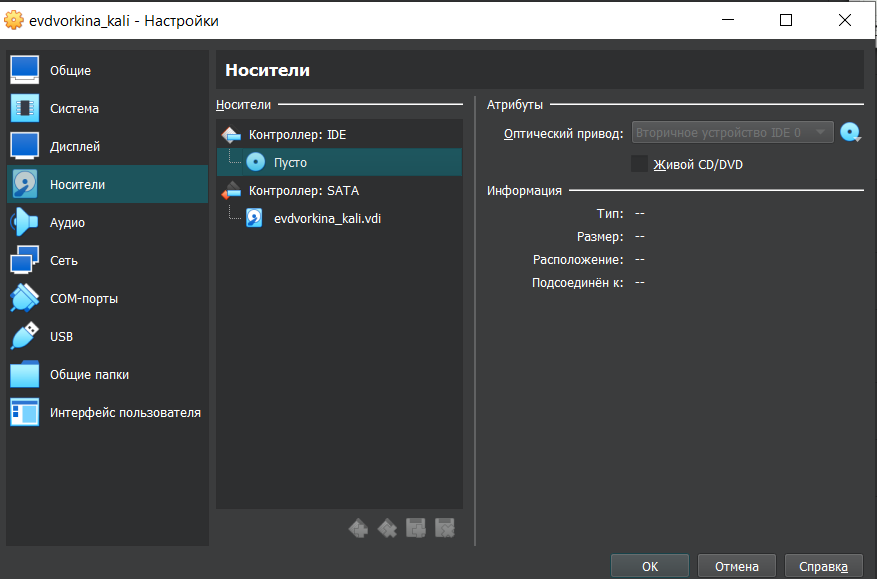

Проверка носителей

## Вход в систему

Вход в систему выполнен успешно, как и ее загрузка

[figure not shown]

Успешная загрузка системы

## Вывод

Приобрела практические навыки по установке операционной системы Linux на виртуальную машину. Установила дистрибутив Kali LInux на VirtualBox.

[output not shown]